# Getting Started with BayesianDEB

## Overview

**BayesianDEB** provides a complete Bayesian framework for Dynamic Energy Budget (DEB) modelling. It wraps pre-written Stan models with a clean R interface for data preparation, model specification, fitting, diagnostics, and visualisation.

The package implements four model types:

| Type | Stan model | Description |
| --- | --- | --- |
| `individual` | 2-state (E, V) | Single individual growth |
| `growth_repro` | 3-state (E, V, R) | Growth + reproduction |
| `hierarchical` | 2-state + random effects | Multi-individual with partial pooling |
| `debtox` | 4-state (E, V, R, D) | Toxicokinetic-toxicodynamic |

## Installation

```r
# Install cmdstanr (required backend)
install.packages("cmdstanr",
  repos = c("https://stan-dev.r-universe.dev", getOption("repos")))
cmdstanr::install_cmdstan()

# Install BayesianDEB
# remotes::install_github("sciom/BayesianDEB")
```

The chunks below are executed only when `cmdstanr` and a working CmdStan installation are available — otherwise they are skipped. To keep build time within JSS limits we use 2 chains and 300 + 300 iterations, which is sufficient for illustration but **not** for publication-grade inference. Re-run with `chains = 4`, `iter_warmup = iter_sampling = 1000` for production fits.

## Example: Individual Growth Model

### 1. Prepare Data

```r
data(eisenia_growth)

# Use first individual
df1 <- eisenia_growth[eisenia_growth$id == 1, ]
dat <- bdeb_data(growth = df1, f_food = 1.0)
dat
```

```
#>
#> ── BDEB Data ──
#>
#> ℹ Individuals: 1
#> ℹ Endpoints: growth
#> ℹ Functional response (f): 1
#> → Growth: 13 observations, t = [0, 84]
```

### 2. Specify Model

```r
mod <- bdeb_model(
  data   = dat,
  type   = "individual",
  priors = list(
    p_Am    = prior_lognormal(mu = 1.5, sigma = 0.5),
    p_M     = prior_lognormal(mu = -1.0, sigma = 0.5),
    kappa   = prior_beta(a = 3, b = 2),
    sigma_L = prior_halfnormal(sigma = 0.05)
  )
)
mod
```

```
#>
#> ── BDEB Model Specification ──
#>
#> ℹ Type: individual
#> ℹ Stan model: bdeb_individual_growth
#> ℹ Individuals: 1
#> ℹ Endpoints: growth
#>
#> ── Priors
#> →   p_Am: LogNormal(1.5, 0.5)
#> →   p_M: LogNormal(-1.0, 0.5)
#> →   kappa: Beta(3.0, 2.0)
#> →   sigma_L: HalfNormal(0.05)
#> →   v: LogNormal(-1.5, 1.0)
#> →   E_G: LogNormal(6.0, 1.0)
#> →   E0: LogNormal(0.0, 1.0)
#> →   L0: LogNormal(-2.0, 1.0)
```

Unspecified priors are filled from `prior_default("individual")`.

### 3. Fit Model

```r
fit <- bdeb_fit(mod,
                chains = 2, iter_warmup = 300, iter_sampling = 300,
                seed = 123, refresh = 100)
```

[output not shown]

```r
fit
```

```
#>
#> ── BDEB Fit ──
#>
#> ℹ Model type: individual
#> ℹ Algorithm: sampling (NUTS)
#> ℹ Chains: 2, Warmup: 300, Sampling: 300
#> ! Divergent transitions: 1
```

### 4. Diagnostics

```r
bdeb_diagnose(fit)
```

```
#>
#> ── BDEB Diagnostics (individual) ──
#>
#> ✖ Divergent transitions: 1
#> ℹ Consider: increase adapt_delta, reparameterise, or tighten priors.
#> ✔ Treedepth OK.
#> ✔ E-BFMI OK (all > 0.3).
#>
#> ── Parameter Summary
#> ✖ R-hat > 1.01 for: v, x_sol[2,1], x_sol[3,1], x_sol[5,1], x_sol[8,2], x_sol[9,2], L_hat[7], L_hat[8], L_hat[9], L_hat[10]
#> ! Low bulk ESS (<400) for: v, E_G, L0, sigma_L, x_sol[1,2], x_sol[2,2], x_sol[3,2], x_sol[4,2], L_hat[1], L_hat[2], L_hat[3], L_hat[4]
#>     variable     mean       sd   median       5%      95%  rhat ess_bulk
#>         p_Am 5.12e+00 2.83e+00 4.49e+00 2.03e+00 1.04e+01 1.001      640
#>          p_M 4.40e-01 2.42e-01 3.90e-01 1.48e-01 9.00e-01 1.000      533
#>        kappa 6.03e-01 1.78e-01 6.15e-01 3.01e-01 8.69e-01 1.008      489
#>            v 3.08e-01 3.20e-01 2.09e-01 5.82e-02 8.84e-01 1.019      240
#>          E_G 4.34e+02 3.36e+02 3.47e+02 1.26e+02 1.04e+03 1.006      281
#>           E0 1.81e+00 3.96e+00 1.05e+00 1.90e-01 5.31e+00 1.000      616
#>           L0 1.09e-01 1.08e-02 1.10e-01 9.03e-02 1.26e-01 0.999      266
#>      sigma_L 1.82e-02 4.51e-03 1.74e-02 1.25e-02 2.64e-02 1.004      358
#>   x_sol[1,1] 2.57e-03 5.50e-03 1.35e-03 2.79e-04 7.44e-03 1.005      552
#>   x_sol[2,1] 3.84e-01 2.28e-01 3.36e-01 1.21e-01 8.47e-01 1.019      578
#>   x_sol[3,1] 7.45e-01 4.68e-01 6.50e-01 2.09e-01 1.66e+00 1.014      588
#>   x_sol[4,1] 1.12e+00 7.24e-01 9.58e-01 2.90e-01 2.50e+00 1.010      593
#>   x_sol[5,1] 1.51e+00 9.99e-01 1.30e+00 3.67e-01 3.43e+00 1.011      600
#>   x_sol[6,1] 1.93e+00 1.29e+00 1.64e+00 4.46e-01 4.40e+00 1.009      605
#>   x_sol[7,1] 2.37e+00 1.61e+00 2.02e+00 5.30e-01 5.44e+00 1.008      616
#>   x_sol[8,1] 2.84e+00 1.94e+00 2.38e+00 6.18e-01 6.43e+00 1.007      620
#>   x_sol[9,1] 3.34e+00 2.30e+00 2.80e+00 7.14e-01 7.59e+00 1.006      622
#>  x_sol[10,1] 3.87e+00 2.68e+00 3.22e+00 8.16e-01 8.75e+00 1.004      627
#>  x_sol[11,1] 4.44e+00 3.08e+00 3.67e+00 9.03e-01 1.01e+01 1.004      632
#>  x_sol[12,1] 5.03e+00 3.51e+00 4.18e+00 9.95e-01 1.16e+01 1.003      635
#>  x_sol[13,1] 5.66e+00 3.95e+00 4.67e+00 1.13e+00 1.32e+01 1.002      636
#>   x_sol[1,2] 1.34e-03 3.85e-04 1.32e-03 7.36e-04 2.01e-03 0.999      266
#>   x_sol[2,2] 1.40e-03 3.60e-04 1.38e-03 8.30e-04 2.05e-03 1.000      281
#>   x_sol[3,2] 1.53e-03 3.26e-04 1.50e-03 9.98e-04 2.08e-03 1.002      299
#>   x_sol[4,2] 1.68e-03 2.94e-04 1.66e-03 1.19e-03 2.18e-03 1.001      361
#>   x_sol[5,2] 1.85e-03 2.69e-04 1.84e-03 1.41e-03 2.33e-03 0.999      549
#>   x_sol[6,2] 2.04e-03 2.58e-04 2.03e-03 1.64e-03 2.49e-03 1.007      628
#>   x_sol[7,2] 2.24e-03 2.66e-04 2.23e-03 1.81e-03 2.72e-03 1.010      687
```

[output cut: 52 more lines]

```
#>       324
#>       295
#>       256
#>       289
#>       354
#>       283
#>       369
#>       410
#>       491
#>       349
#>       308
#>       312
#>       292
#>       324
#>       295
```

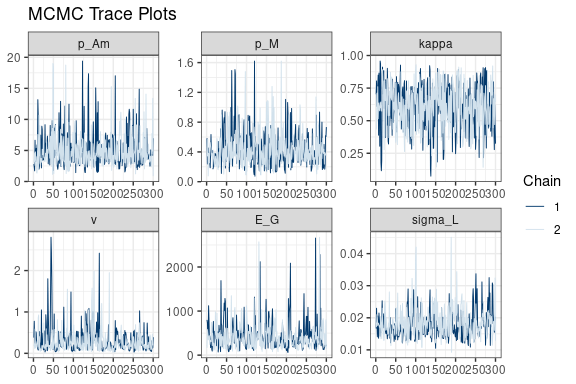

```r
plot(fit, type = "trace")
```

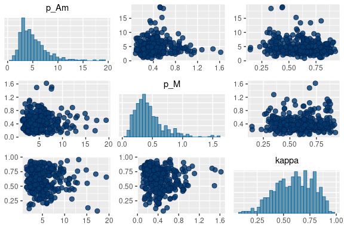

```r
# `bayesplot::mcmc_pairs` requires gridExtra (a Suggests of bayesplot).
plot(fit, type = "pairs", pars = c("p_Am", "p_M", "kappa"))
```

### 5. Posterior Predictive Checks

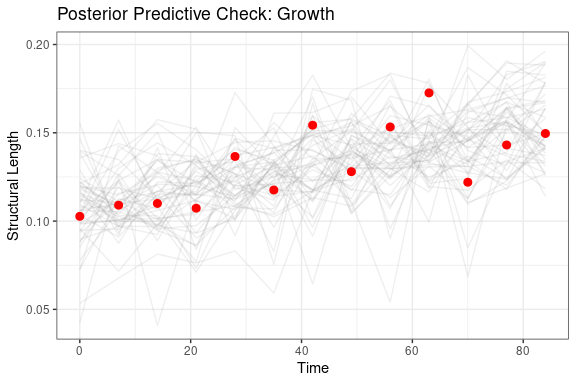

```r
ppc <- bdeb_ppc(fit, type = "growth")
plot(ppc)
```

### 6. Derived Quantities

```r
bdeb_derived(fit, quantities = c("L_inf", "growth_rate"))
```

```
#> # A draws_df: 600 iterations, 1 chains, and 2 variables
#>    L_inf growth_rate
#> 1    3.4     2.4e-04
#> 2    7.9     1.1e-04
#> 3    3.7     2.5e-04
#> 4   10.1     2.6e-04
#> 5    9.6     7.8e-05
#> 6    6.9     1.6e-04
#> 7    5.5     3.1e-04
#> 8   14.7     1.8e-04
#> 9   22.5     1.7e-04
#> 10   3.9     7.2e-04
#> # ... with 590 more draws
#> # ... hidden reserved variables {'.chain', '.iteration', '.draw'}
```

### 7. Trajectory Plot

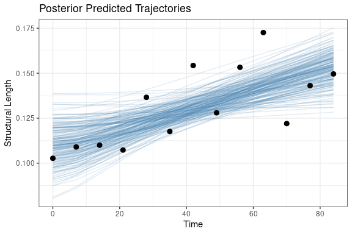

```r
plot(fit, type = "trajectory", n_draws = 200)
```

## Example: Hierarchical Model (Multiple Individuals)

For illustration we use a 5-individual subset; the full multi-individual analysis with all 21 individuals is in the replication archive.

```r
dat_all <- bdeb_data(
  growth = eisenia_growth[eisenia_growth$id %in% 1:5, ],
  f_food = 1.0
)

mod_hier <- bdeb_model(dat_all, type = "hierarchical")

fit_hier <- bdeb_fit(mod_hier,
                     chains = 2, iter_warmup = 300, iter_sampling = 300,
                     seed = 123, refresh = 100)
```

[output not shown]

```r
bdeb_diagnose(fit_hier)
```

```
#>
#> ── BDEB Diagnostics (hierarchical) ──
#>
#> ✖ Divergent transitions: 1
#> ℹ Consider: increase adapt_delta, reparameterise, or tighten priors.
#> ✔ Treedepth OK.
#> ✔ E-BFMI OK (all > 0.3).
#>
#> ── Parameter Summary
#> ✖ R-hat > 1.01 for: E_G, L0[2], sigma_L
#> ! Low bulk ESS (<400) for: sigma_log_p_Am, p_M, E_G, L0[2]
#>        variable     mean       sd   median      5%      95%  rhat ess_bulk
#>     mu_log_p_Am   1.5842 8.79e-01   1.5068  0.2011   3.0610 1.005      586
#>  sigma_log_p_Am   0.6325 6.23e-01   0.4692  0.0328   1.9584 1.006      295
#>   z_log_p_Am[1]   0.3045 9.28e-01   0.3601 -1.1956   1.7752 0.998      835
#>   z_log_p_Am[2]   0.5997 9.04e-01   0.5943 -0.9779   2.0966 0.999      617
#>   z_log_p_Am[3]  -0.1359 8.89e-01  -0.1856 -1.5402   1.3851 1.005      626
#>   z_log_p_Am[4]  -0.1774 8.58e-01  -0.2179 -1.5047   1.2190 1.002      585
#>   z_log_p_Am[5]  -0.0632 8.74e-01  -0.0498 -1.4727   1.3491 1.004      416
#>             p_M   1.4813 1.36e+00   1.1287  0.1196   4.0937 1.000      344
#>           kappa   0.5327 2.06e-01   0.5179  0.2123   0.8750 1.004      661
#>             E_G 197.8070 1.99e+02 123.1590 35.5848 593.4928 1.013      240
#>              E0   1.7334 2.08e+00   1.0248  0.2173   5.8179 0.997      811
#>           L0[1]   0.1065 8.89e-03   0.1065  0.0918   0.1210 0.998      598
#>           L0[2]   0.0770 1.40e-02   0.0783  0.0520   0.0970 1.024      186
#>           L0[3]   0.0963 9.10e-03   0.0963  0.0814   0.1114 1.005      610
#>           L0[4]   0.1019 8.45e-03   0.1023  0.0886   0.1152 1.010      457
#>           L0[5]   0.1093 9.12e-03   0.1090  0.0939   0.1240 1.007      518
#>         sigma_L   0.0163 1.49e-03   0.0162  0.0142   0.0191 1.011      653
#>     p_Am_ind[1]  26.9636 2.09e+02   5.7046  1.3512  46.0168 0.999      625
#>     p_Am_ind[2]  44.8645 6.43e+02   6.9541  1.4925  53.5077 1.004      559
#>     p_Am_ind[3]  12.3004 7.33e+01   4.1962  1.0188  28.2552 1.000      509
#>     p_Am_ind[4]  46.9554 9.33e+02   3.8473  1.0163  27.3200 1.003      477
#>     p_Am_ind[5]   9.9224 2.52e+01   4.2062  0.9494  31.9906 1.004      536
#>  ess_tail
#>       514
#>       370
#>       469
#>       544
#>       436
#>       460
#>       396
#>       403
#>       269
#>       443
#>       432
#>       383
#>       394
#>       165
#>       348
#>       482
#>       312
#>       419
#>       604
#>       595
#>       515
#>       497
#>       622
```

```r
summary(fit_hier, pars = c("mu_log_p_Am", "sigma_log_p_Am", "p_M", "kappa"))
```

```
#> # A tibble: 4 × 9
#>   variable        mean    sd median   `5%` `95%`  rhat ess_bulk ess_tail
#>   <chr>          <dbl> <dbl>  <dbl>  <dbl> <dbl> <dbl>    <dbl>    <dbl>
#> 1 mu_log_p_Am    1.58  0.879  1.51  0.201  3.06  1.00      586.     514.
#> 2 sigma_log_p_Am 0.632 0.623  0.469 0.0328 1.96  1.01      295.     370.
#> 3 p_M            1.48  1.36   1.13  0.120  4.09  1.000     344.     403.
#> 4 kappa          0.533 0.206  0.518 0.212  0.875 1.00      661.     269.
```

## Example: DEBtox Model

```r
data(debtox_growth)

# Concentration mapping
conc_map <- setNames(
  c(0, 20, 80, 200),
  c("1", "2", "3", "4")
)

dat_tox <- bdeb_data(
  growth = debtox_growth,
  concentration = conc_map,
  f_food = 1.0
)

mod_tox <- bdeb_tox(dat_tox, stress = "assimilation")
```

For this **demo only**, we use **variational inference (ADVI)** which gives an approximation of the posterior in seconds rather than minutes. The replication archive uses full HMC (NUTS) which is the publication-grade method.

```r
fit_tox <- bdeb_fit(mod_tox, algorithm = "variational",
                    seed = 123, refresh = 0)
```

[output not shown]

```r
bdeb_ec50(fit_tox)
```

```
#>
#> ── DEBtox Effect Concentrations
#>  parameter   mean median    sd   lower upper
#>       EC50 214.43 172.74 168.6 55.5600 522.5
#>        NEC   6.62   1.13  22.2  0.0606  27.1
```

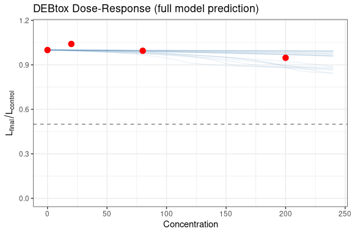

```r
plot_dose_response(fit_tox, n_draws = 20, n_conc = 25, dt = 1.0)
```

## Prior Specification

BayesianDEB follows the prior recommendations of Kooijman (2010) and the AmP collection (Marques et al., 2018):

- **Positive rate parameters** (p_Am, p_M, v, E_G): Log-normal priors
- **Allocation fraction** (kappa): Beta prior
- **Scale parameters** (sigma_L): Half-normal priors
- **Hierarchical SDs**: Exponential priors

```r
# View defaults
prior_default("individual")
```

```
#> $p_Am
#> → lognormal(mu = 1, sigma = 1)
#>
#> $p_M
#> → lognormal(mu = -1, sigma = 1)
#>
#> $kappa
#> → beta(a = 2, b = 2)
#>
#> $v
#> → lognormal(mu = -1.5, sigma = 1)
#>
#> $E_G
#> → lognormal(mu = 6, sigma = 1)
#>
#> $E0
#> → lognormal(mu = 0, sigma = 1)
#>
#> $L0
#> → lognormal(mu = -2, sigma = 1)
#>
#> $sigma_L
#> → halfnormal(sigma = 0.1)
```

```r
# Override specific priors
my_priors <- list(
  p_Am  = prior_lognormal(mu = 2.0, sigma = 0.3),
  kappa = prior_beta(a = 5, b = 2)
)
```

## Observation Models

The default likelihood is Gaussian for growth and negative binomial for reproduction. Switch via `observation`:

```r
# Robust to outliers
mod <- bdeb_model(dat, type = "individual",
  observation = list(growth = obs_student_t(nu = 5)))

# Multiplicative error
mod <- bdeb_model(dat, type = "individual",
  observation = list(growth = obs_lognormal()))
```

## Further Reading

- Kooijman, S.A.L.M. (2010). *Dynamic Energy Budget Theory for Metabolic Organisation*. 3rd edition. Cambridge University Press.
- Jager, T., Heugens, E.H.W. and Kooijman, S.A.L.M. (2006). Making sense of ecotoxicological test results: towards application of process-based models. *Ecotoxicology*, 15(3), 305–314.
- Carpenter, B. et al. (2017). Stan: A probabilistic programming language. *Journal of Statistical Software*, 76(1).
- Gelman, A. et al. (2013). *Bayesian Data Analysis*. 3rd edition. Chapman & Hall/CRC.